# Cardiovascular diseases

### 2.1.4 Wave 4

#### 2.1.4.1 Study-specific variable description

| **Name** | `hedimhf` | `hedimhm` | `h_angina` | `mi_ha` | `stroke` |
| --- | --- | --- | --- | --- | --- |
| **Label** | `CVD: congestive heart failure diagnosis newly reported (merged)` | `CVD: heart murmur diagnosis newly reported (merged)` | `History of angina` | `Myocardial infarction or heart attack` | `Stroke` |
| **Table name** | `wave_4_elsa_data_v3` | `wave_4_elsa_data_v3` | `h_angina` | `mi_ha` | `stroke` |
| **Categories** | `1 = Mentioned` `0 = Not mentioned` | `1 = Mentioned` `0 = Not mentioned` | `0 = no history of angina` `1 = history of angina` | `0 = No` `1 = Yes` | `0 = NOT A stroke (cerebral vascular disease)` `1 = A stroke (cerebral vascular disease)` |
| **Missings** | `-9 = Refusal` `-8 = Don't know` `-1 = Not applicable` | `-9 = Refusal` `-8 = Don't know` `-1 = Not applicable` | `997 = Refuse` `998 = Do not know` | `997 = Refuse` `998 = Do not know` | `997 = Refuse` `998 = Do not know` |
| **Description** |  |  |  |  |  |

hedimhf

| Sample size | Missing values |
| --- | --- |
| 11050 | 16 |

Category

|  | 0 | 1 |
| --- | --- | --- |
| Frequency | 11002.00 | 32.00 |
| Percentage | 99.57 | 0.29 |

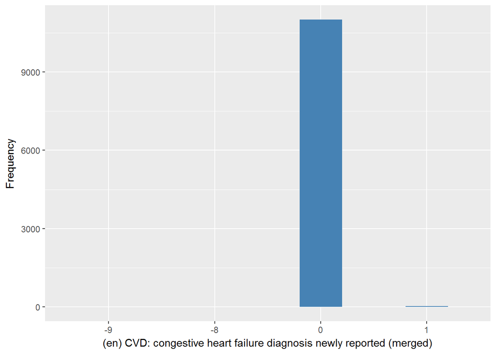

hedimhm

| Sample size | Missing values |
| --- | --- |
| 11050 | 16 |

Category

|  | 0 | 1 |
| --- | --- | --- |
| Frequency | 10910.00 | 124.00 |
| Percentage | 98.73 | 1.12 |

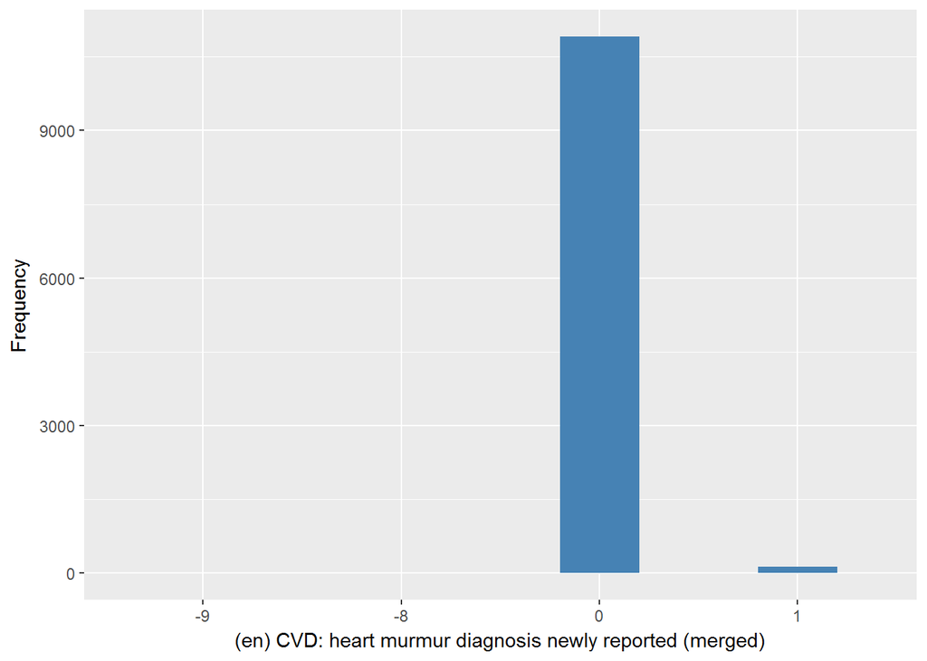

h_angina

| Sample size | Missing values |
| --- | --- |
| 11050 | 16 |

Category

|  | 0 | 1 |
| --- | --- | --- |
| Frequency | 10101.00 | 933.00 |
| Percentage | 91.41 | 8.44 |

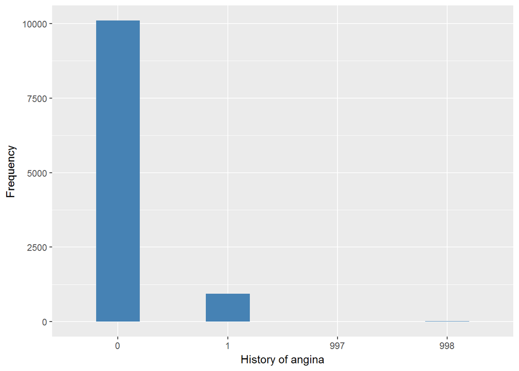

mi_ha

| Sample size | Missing values |
| --- | --- |
| 11050 | 16 |

Category

|  | 0 | 1 |
| --- | --- | --- |
| Frequency | 10894.00 | 140.00 |
| Percentage | 98.59 | 1.27 |

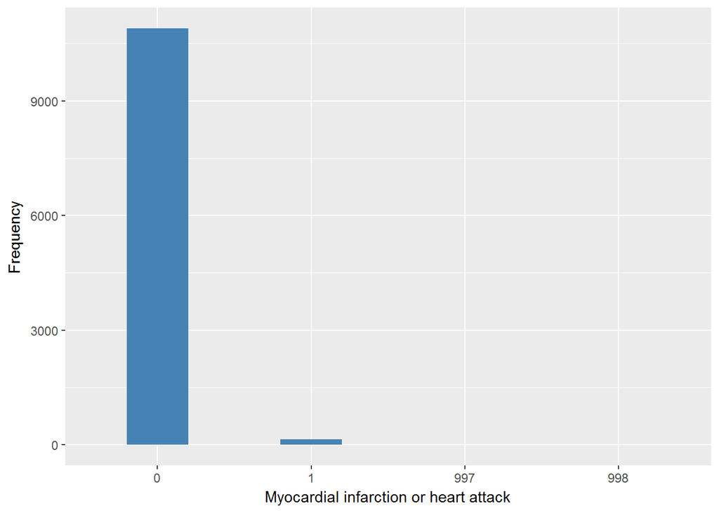

stroke

| Sample size | Missing values |
| --- | --- |
| 11050 | 16 |

Category

|  | 0 | 1 |
| --- | --- | --- |
| Frequency | 10851.0 | 183.00 |
| Percentage | 98.2 | 1.66 |

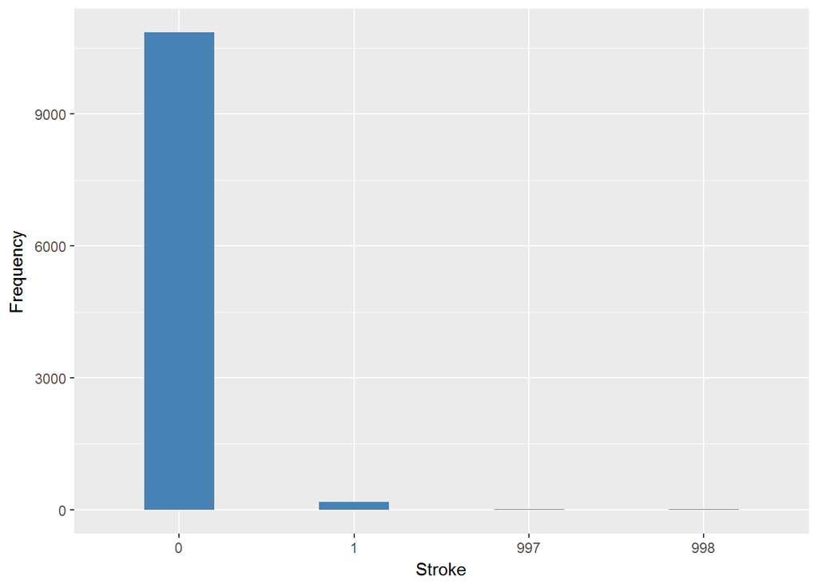

#### 2.1.4.2 Harmonisation algorithm

To compute `cvd_all` from the study-specific variable it has to be recoded as follows:

- `some 1 into 1`
- `all 0 into 0`
- `-9/997 into 997`
- `-8/998 into 998`

**R script:**

```r
# Categorical variable harmonization
ELSA_ds_w4 <- tibble(id = ELSA_w4$id)
ELSA_ds_w4$cvd_all <- rep(999, length(ELSA_w4$id))
ELSA_ds_w4$cvd_all[which(ELSA_w4$h_angina == 0 & ELSA_w4$mi_ha == 0 & ELSA_w4$stroke ==
    0 & ELSA_w4$hedimhf == 0 & ELSA_w4$hedimhm == 0)] <- 0
ELSA_ds_w4$cvd_all[which(ELSA_w4$h_angina == 1 | ELSA_w4$mi_ha == 1 | ELSA_w4$stroke ==
    1 | ELSA_w4$hedimhf == 1 | ELSA_w4$hedimhm == 1)] <- 1
ELSA_ds_w4$cvd_all[which(ELSA_w4$h_angina == 998 & ELSA_w4$mi_ha == 998 & ELSA_w4$stroke ==
    998 & ELSA_w4$hedimhf == -8 & ELSA_w4$hedimhm == -8)] <- 998
ELSA_ds_w4$cvd_all[which(ELSA_w4$h_angina == 997 & ELSA_w4$mi_ha == 997 & ELSA_w4$stroke ==
    997 & ELSA_w4$hedimhf == -9 & ELSA_w4$hedimhm == -9)] <- 997
```

#### 2.1.4.3 Statistics of the new harmonized variable

History of all Cardiovascular diseases

| Sample size | Missing values |
| --- | --- |
| 11050 | 16 |

Category

|  | 0 | 1 |
| --- | --- | --- |
| Frequency | 9785.00 | 1249.0 |
| Percentage | 88.55 | 11.3 |

Type of missing

|  | 991 | 992 | 993 | 994 | 995 | 996 | 997 | 998 | 999 | NA |
| --- | --- | --- | --- | --- | --- | --- | --- | --- | --- | --- |
| Frequency | 0 | 0 | 0 | 0 | 0 | 0 | 7.00 | 9.00 | 0 | 0 |
| Percentage | 0 | 0 | 0 | 0 | 0 | 0 | 0.06 | 0.08 | 0 | 0 |

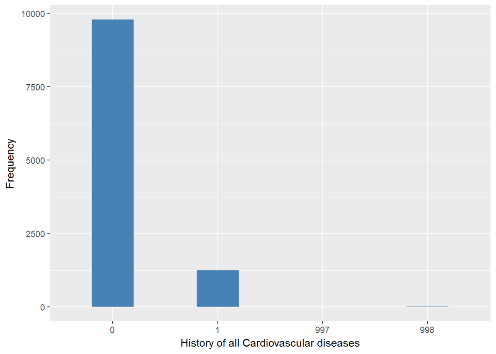

#### 2.1.4.4 Validation

|  | all 0->0 | some 1->1 | -9/997->997 | -8/998->998 |
| --- | --- | --- | --- | --- |
| BeforeH | 9785 | 1249 | 7 | 9 |
| AfterH | 9785 | 1249 | 7 | 9 |

### 2.1.5 Wave 5

#### 2.1.5.1 Study-specific variable description

| **Name** | `hedimhf` | `hedimhm` | `h_angina` | `mi_ha` | `stroke` |
| --- | --- | --- | --- | --- | --- |
| **Label** | `CVD: congestive heart failure diagnosis newly reported (merged)` | `CVD: heart murmur diagnosis newly reported (merged)` | `History of angina` | `Myocardial infarction or heart attack` | `Stroke` |
| **Table name** | `wave_5_elsa_data_v4` | `wave_5_elsa_data_v4` | `h_angina` | `mi_ha` | `stroke` |
| **Categories** | `1 = Mentioned` `0 = Not mentioned` | `1 = Mentioned` `0 = Not mentioned` | `0 = no history of angina` `1 = history of angina` | `0 = No` `1 = Yes` | `0 = NOT A stroke (cerebral vascular disease)` `1 = A stroke (cerebral vascular disease)` |
| **Missings** | `-9 = Refusal` `-8 = Don't know` `-1 = Not applicable` | `-9 = Refusal` `-8 = Don't know` `-1 = Not applicable` | `997 = Refuse` `998 = Do not know` | `997 = Refuse` `998 = Do not know` | `997 = Refuse` `998 = Do not know` |
| **Description** |  |  |  |  |  |

hedimhf

| Sample size | Missing values |
| --- | --- |
| 10274 | 15 |

Category

|  | 0 | 1 |
| --- | --- | --- |
| Frequency | 10232.00 | 27.00 |
| Percentage | 99.59 | 0.26 |

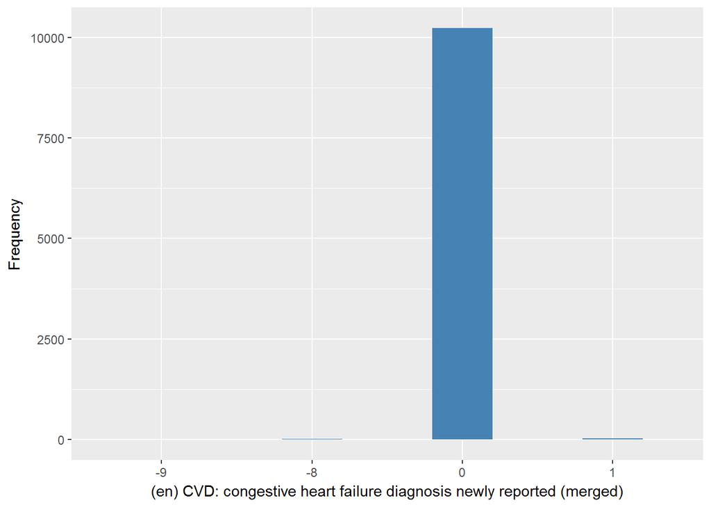

hedimhm

| Sample size | Missing values |
| --- | --- |
| 10274 | 15 |

Category

|  | 0 | 1 |
| --- | --- | --- |
| Frequency | 10139.00 | 120.00 |
| Percentage | 98.69 | 1.17 |

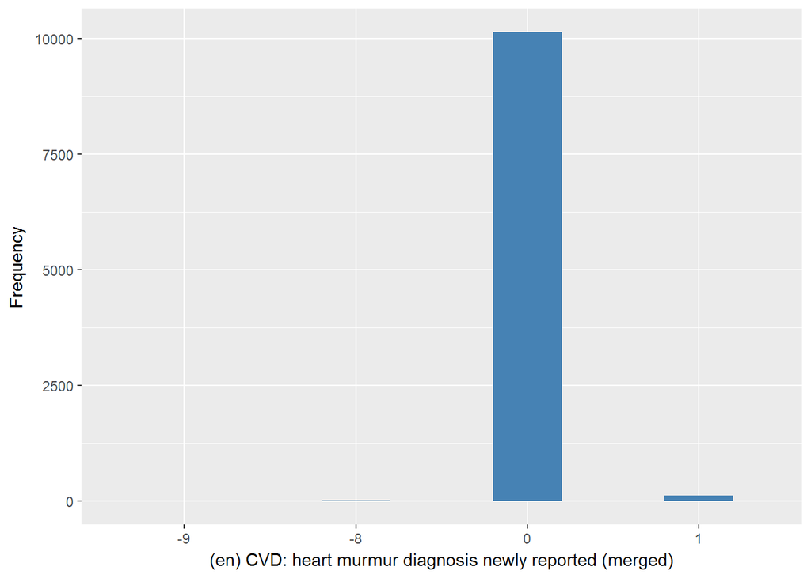

h_angina

| Sample size | Missing values |
| --- | --- |
| 10274 | 13 |

Category

|  | 0 | 1 |
| --- | --- | --- |
| Frequency | 9359.00 | 902.00 |
| Percentage | 91.09 | 8.78 |

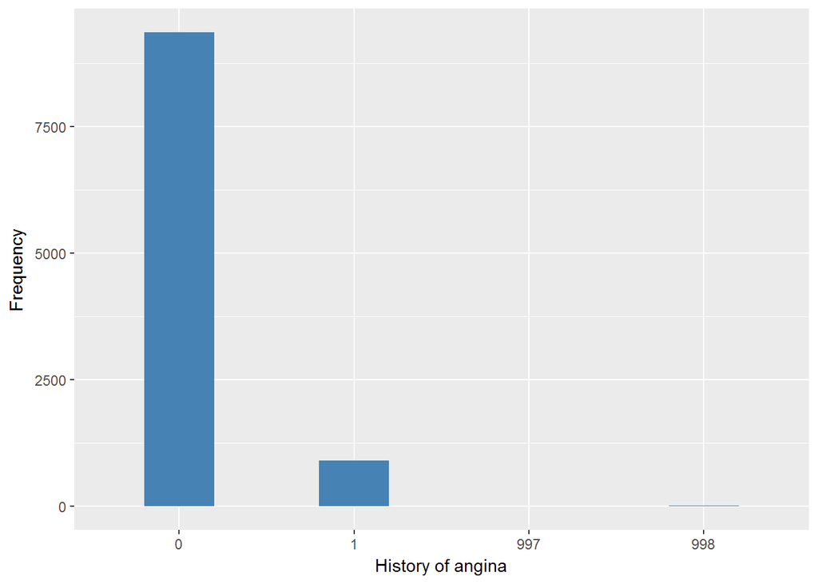

mi_ha

| Sample size | Missing values |
| --- | --- |
| 10274 | 15 |

Category

|  | 0 | 1 |
| --- | --- | --- |
| Frequency | 10137.00 | 122.00 |
| Percentage | 98.67 | 1.19 |

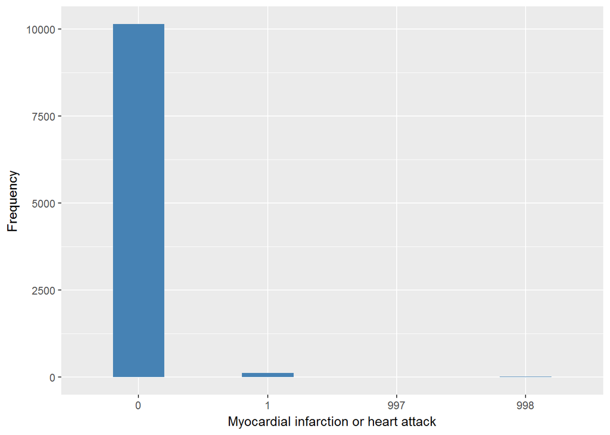

stroke

| Sample size | Missing values |
| --- | --- |
| 10274 | 15 |

Category

|  | 0 | 1 |
| --- | --- | --- |
| Frequency | 10110.0 | 149.00 |
| Percentage | 98.4 | 1.45 |

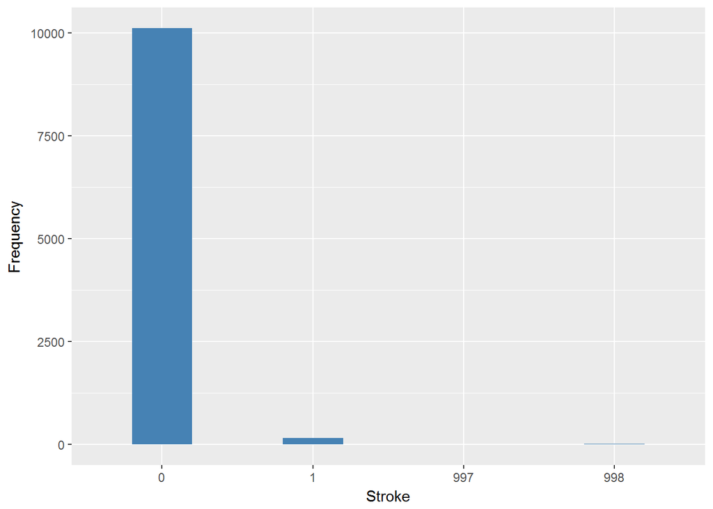

#### 2.1.5.2 Harmonisation algorithm

To compute `cvd_all` from the study-specific variable it has to be recoded as follows:

- `some 1 into 1`
- `all 0 into 0`
- `-9/997 into 997`
- `-8/998 into 998`

**R script:**

```r
# Categorical variable harmonization
ELSA_ds_w5 <- tibble(id = ELSA_w5$id)
ELSA_ds_w5$cvd_all <- rep(999, length(ELSA_w5$id))
ELSA_ds_w5$cvd_all[which(ELSA_w5$h_angina == 0 & ELSA_w5$mi_ha == 0 & ELSA_w5$stroke ==
    0 & ELSA_w5$hedimhf == 0 & ELSA_w5$hedimhm == 0)] <- 0
ELSA_ds_w5$cvd_all[which(ELSA_w5$h_angina == 1 | ELSA_w5$mi_ha == 1 | ELSA_w5$stroke ==
    1 | ELSA_w5$hedimhf == 1 | ELSA_w5$hedimhm == 1)] <- 1
ELSA_ds_w5$cvd_all[which(ELSA_w5$h_angina == 998 & ELSA_w5$mi_ha == 998 & ELSA_w5$stroke ==
    998 & ELSA_w5$hedimhf == -8 & ELSA_w5$hedimhm == -8)] <- 998
ELSA_ds_w5$cvd_all[which(ELSA_w5$h_angina == 997 & ELSA_w5$mi_ha == 997 & ELSA_w5$stroke ==
    997 & ELSA_w5$hedimhf == -9 & ELSA_w5$hedimhm == -9)] <- 997
```

#### 2.1.5.3 Statistics of the new harmonized variable

History of all Cardiovascular diseases

| Sample size | Missing values |
| --- | --- |
| 10274 | 13 |

Category

|  | 0 | 1 |
| --- | --- | --- |
| Frequency | 9085.00 | 1176.00 |
| Percentage | 88.43 | 11.45 |

Type of missing

|  | 991 | 992 | 993 | 994 | 995 | 996 | 997 | 998 | 999 | NA |
| --- | --- | --- | --- | --- | --- | --- | --- | --- | --- | --- |
| Frequency | 0 | 0 | 0 | 0 | 0 | 0 | 4.00 | 9.00 | 0 | 0 |
| Percentage | 0 | 0 | 0 | 0 | 0 | 0 | 0.04 | 0.09 | 0 | 0 |

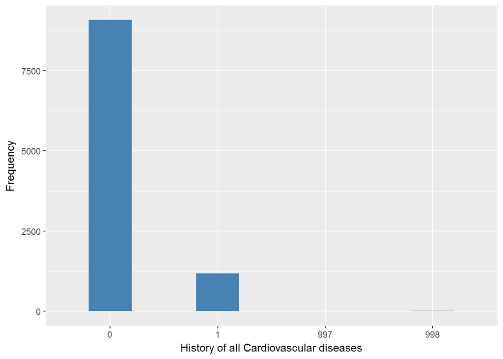

#### 2.1.5.4 Validation

|  | all 0->0 | some 1->1 | -9/997->997 | -8/998->998 |
| --- | --- | --- | --- | --- |
| BeforeH | 9085 | 1176 | 4 | 9 |
| AfterH | 9085 | 1176 | 4 | 9 |

### 2.1.6 Wave 6

#### 2.1.6.1 Study-specific variable description

| **Name** | `hedimhf` | `hedimhm` | `h_angina` | `mi_ha` | `stroke` |
| --- | --- | --- | --- | --- | --- |
| **Label** | `CVD: congestive heart failure diagnosis newly reported (merged)` | `CVD: heart murmur diagnosis newly reported (merged)` | `History of angina` | `Myocardial infarction or heart attack` | `Stroke` |
| **Table name** | `wave_6_elsa_data_v2` | `wave_6_elsa_data_v2` | `h_angina` | `mi_ha` | `stroke` |
| **Categories** | `1 = Mentioned` `0 = Not mentioned` | `1 = Mentioned` `0 = Not mentioned` | `0 = no history of angina` `1 = history of angina` | `0 = No` `1 = Yes` | `0 = NOT A stroke (cerebral vascular disease)` `1 = A stroke (cerebral vascular disease)` |
| **Missings** | `-9 = Refusal` `-8 = Don't know` `-1 = Not applicable` | `-9 = Refusal` `-8 = Don't know` `-1 = Not applicable` | `997 = Refuse` `998 = Do not know` | `997 = Refuse` `998 = Do not know` | `997 = Refuse` `998 = Do not know` |
| **Description** |  |  |  |  |  |

hedimhf

| Sample size | Missing values |
| --- | --- |
| 10601 | 11 |

Category

|  | 0 | 1 |
| --- | --- | --- |
| Frequency | 10564.00 | 26.00 |
| Percentage | 99.65 | 0.25 |

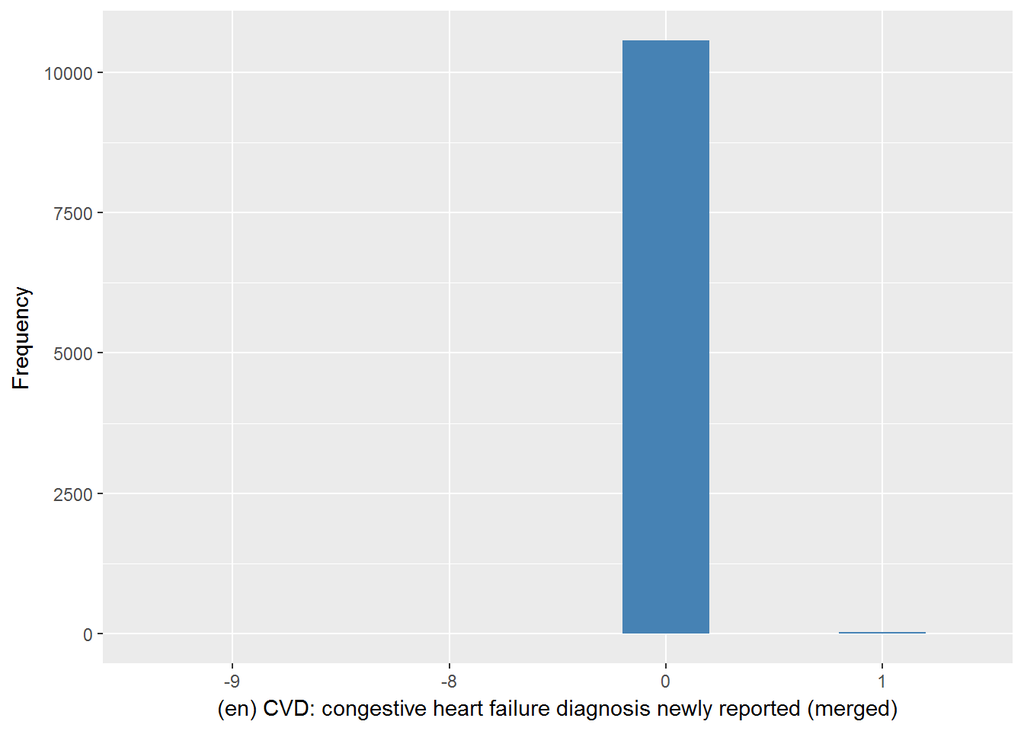

hedimhm

| Sample size | Missing values |
| --- | --- |
| 10601 | 11 |

Category

|  | 0 | 1 |
| --- | --- | --- |
| Frequency | 10470.00 | 120.00 |
| Percentage | 98.76 | 1.13 |

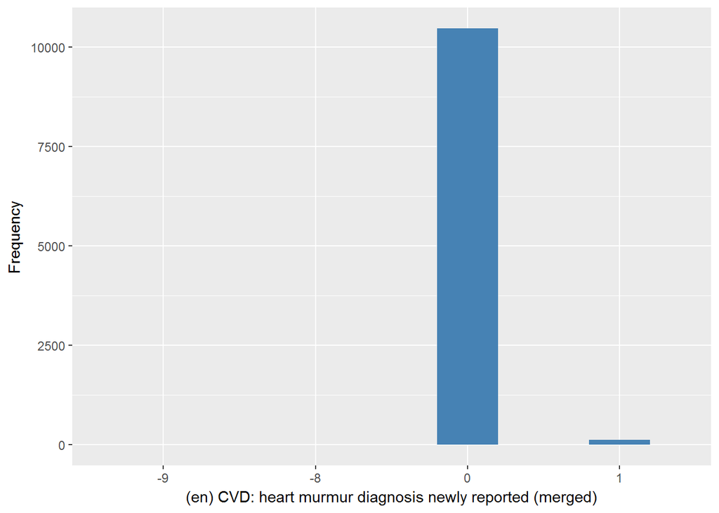

h_angina

| Sample size | Missing values |
| --- | --- |
| 10601 | 10 |

Category

|  | 0 | 1 |
| --- | --- | --- |
| Frequency | 9745.00 | 846.00 |
| Percentage | 91.93 | 7.98 |

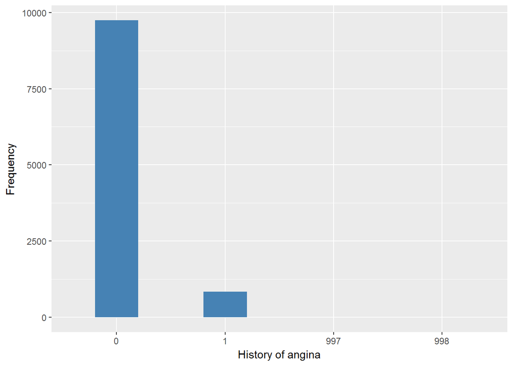

mi_ha

| Sample size | Missing values |
| --- | --- |
| 10601 | 11 |

Category

|  | 0 | 1 |
| --- | --- | --- |
| Frequency | 10462.00 | 128.00 |
| Percentage | 98.69 | 1.21 |

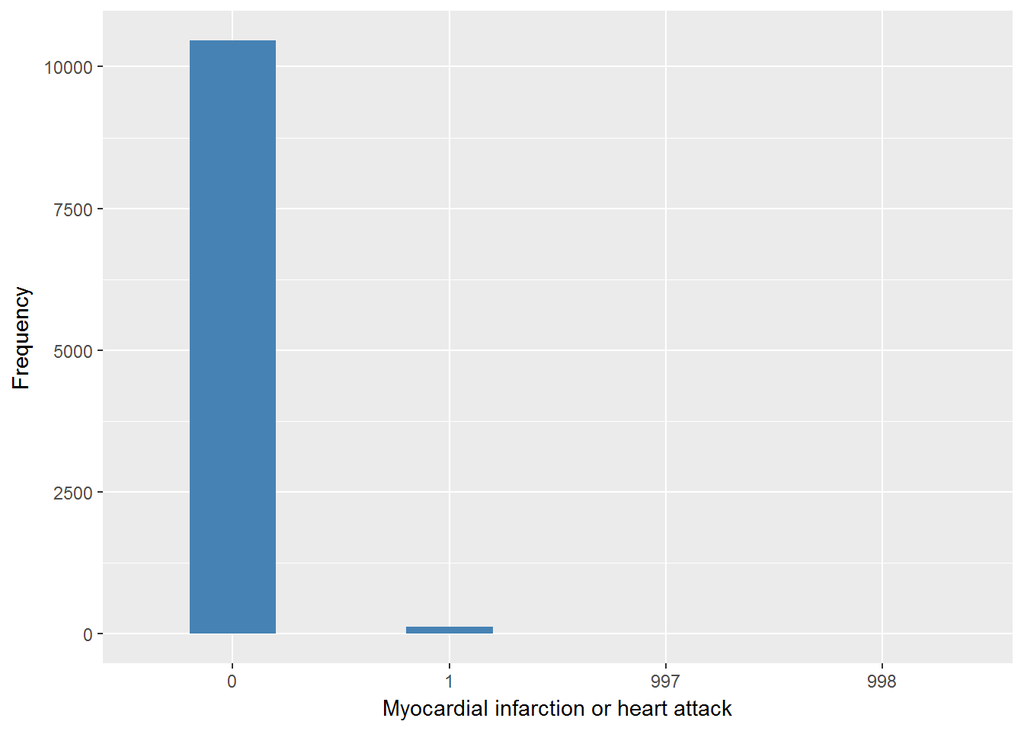

stroke

| Sample size | Missing values |
| --- | --- |
| 10601 | 11 |

Category

|  | 0 | 1 |
| --- | --- | --- |
| Frequency | 10432.00 | 158.00 |
| Percentage | 98.41 | 1.49 |

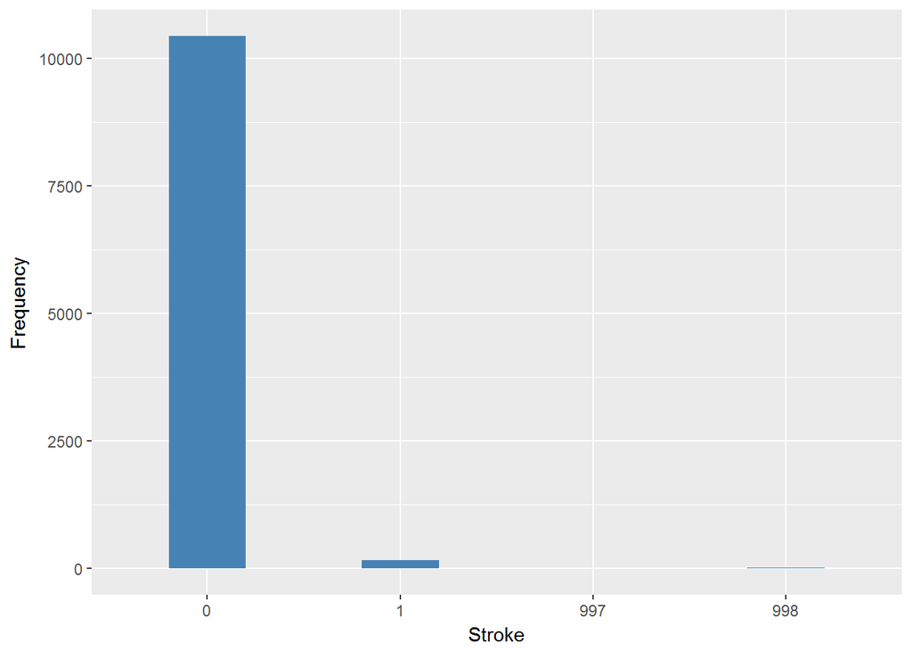

#### 2.1.6.2 Harmonisation algorithm

To compute `cvd_all` from the study-specific variable it has to be recoded as follows:

- `some 1 into 1`
- `all 0 into 0`
- `-9/997 into 997`
- `-8/998 into 998`

**R script:**

```r
# Categorical variable harmonization
ELSA_ds_w6 <- tibble(id = ELSA_w6$id)
ELSA_ds_w6$cvd_all <- rep(999, length(ELSA_w6$id))
ELSA_ds_w6$cvd_all[which(ELSA_w6$h_angina == 0 & ELSA_w6$mi_ha == 0 & ELSA_w6$stroke ==
    0 & ELSA_w6$hedimhf == 0 & ELSA_w6$hedimhm == 0)] <- 0
ELSA_ds_w6$cvd_all[which(ELSA_w6$h_angina == 1 | ELSA_w6$mi_ha == 1 | ELSA_w6$stroke ==
    1 | ELSA_w6$hedimhf == 1 | ELSA_w6$hedimhm == 1)] <- 1
ELSA_ds_w6$cvd_all[which(ELSA_w6$h_angina == 998 & ELSA_w6$mi_ha == 998 & ELSA_w6$stroke ==
    998 & ELSA_w6$hedimhf == -8 & ELSA_w6$hedimhm == -8)] <- 998
ELSA_ds_w6$cvd_all[which(ELSA_w6$h_angina == 997 & ELSA_w6$mi_ha == 997 & ELSA_w6$stroke ==
    997 & ELSA_w6$hedimhf == -9 & ELSA_w6$hedimhm == -9)] <- 997
```

#### 2.1.6.3 Statistics of the new harmonized variable

History of all Cardiovascular diseases

| Sample size | Missing values |
| --- | --- |
| 10601 | 10 |

Category

|  | 0 | 1 |
| --- | --- | --- |
| Frequency | 9464.00 | 1127.00 |
| Percentage | 89.27 | 10.63 |

Type of missing

|  | 991 | 992 | 993 | 994 | 995 | 996 | 997 | 998 | 999 | NA |
| --- | --- | --- | --- | --- | --- | --- | --- | --- | --- | --- |
| Frequency | 0 | 0 | 0 | 0 | 0 | 0 | 4.00 | 6.00 | 0 | 0 |
| Percentage | 0 | 0 | 0 | 0 | 0 | 0 | 0.04 | 0.06 | 0 | 0 |

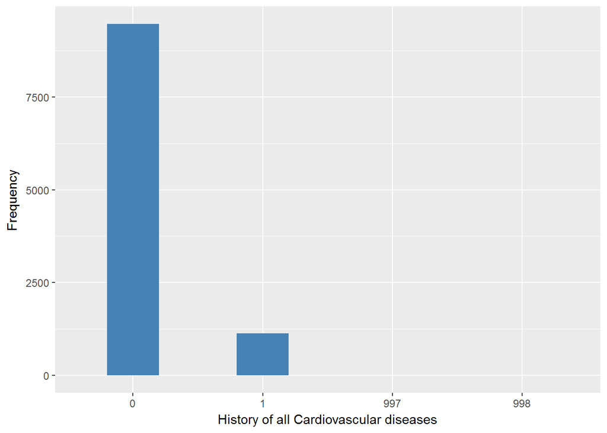

#### 2.1.6.4 Validation

|  | all 0->0 | some 1->1 | -9/997->997 | -8/998->998 |
| --- | --- | --- | --- | --- |
| BeforeH | 9464 | 1127 | 4 | 6 |
| AfterH | 9464 | 1127 | 4 | 6 |

### 2.1.7 Wave 7

#### 2.1.7.1 Study-specific variable description

| **Name** | `hedimhf` | `hedimhm` | `h_angina` | `mi_ha` | `stroke` |
| --- | --- | --- | --- | --- | --- |
| **Label** | `CVD: congestive heart failure diagnosis newly reported (merged)` | `CVD: heart murmur diagnosis newly reported (merged)` | `History of angina` | `Myocardial infarction or heart attack` | `Stroke` |
| **Table name** | `wave_7_elsa_data` | `wave_7_elsa_data` | `h_angina` | `mi_ha` | `stroke` |
| **Categories** | `1 = Mentioned` `0 = Not mentioned` | `1 = Mentioned` `0 = Not mentioned` | `0 = no history of angina` `1 = history of angina` | `0 = No` `1 = Yes` | `0 = NOT A stroke (cerebral vascular disease)` `1 = A stroke (cerebral vascular disease)` |
| **Missings** | `-9 = Refusal` `-8 = Don't know` `-1 = Not applicable` | `-9 = Refusal` `-8 = Don't know` `-1 = Not applicable` | `997 = Refuse` `998 = Do not know` | `997 = Refuse` `998 = Do not know` | `997 = Refuse` `998 = Do not know` |
| **Description** |  |  |  |  |  |

hedimhf

| Sample size | Missing values |
| --- | --- |
| 9666 | 6 |

Category

|  | 0 | 1 |
| --- | --- | --- |
| Frequency | 9623.00 | 37.00 |
| Percentage | 99.56 | 0.38 |

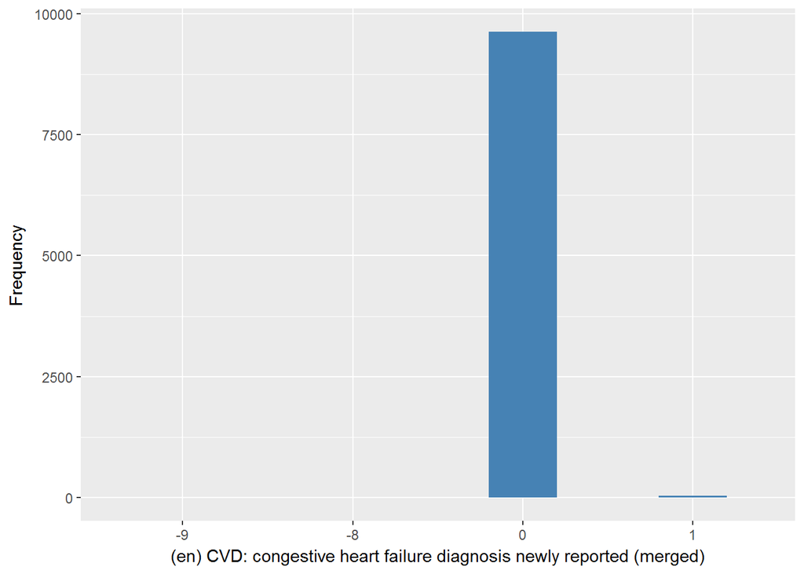

hedimhm

| Sample size | Missing values |
| --- | --- |
| 9666 | 6 |

Category

|  | 0 | 1 |
| --- | --- | --- |
| Frequency | 9555.00 | 105.00 |
| Percentage | 98.85 | 1.09 |

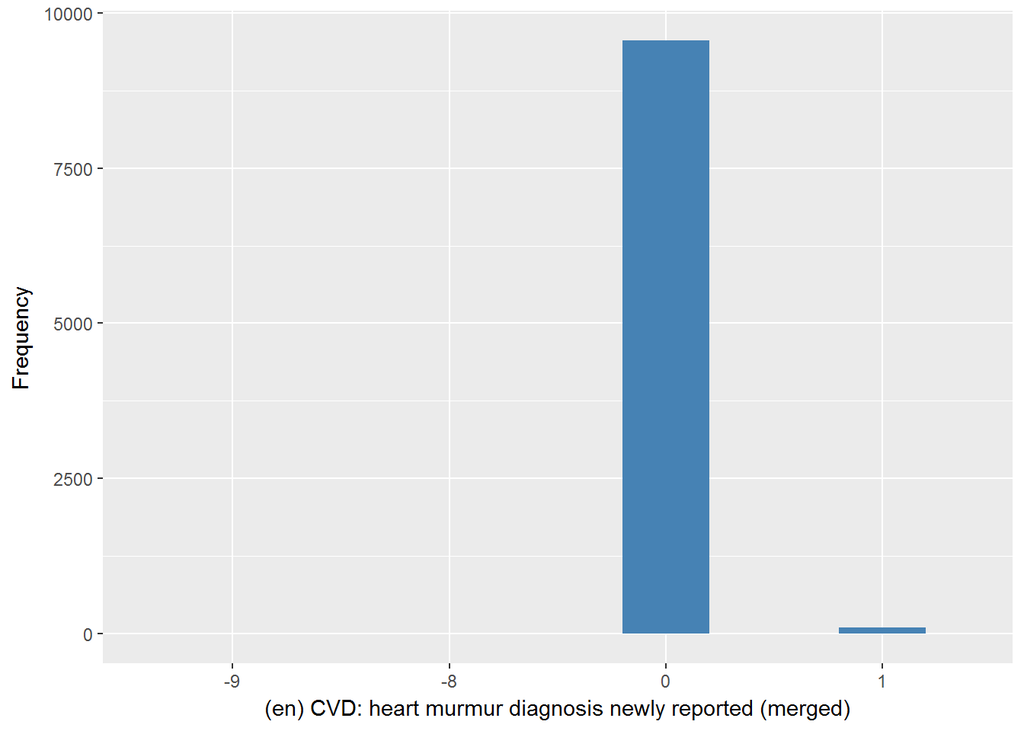

h_angina

| Sample size | Missing values |
| --- | --- |
| 9666 | 6 |

Category

|  | 0 | 1 |
| --- | --- | --- |
| Frequency | 8908.00 | 752.00 |
| Percentage | 92.16 | 7.78 |

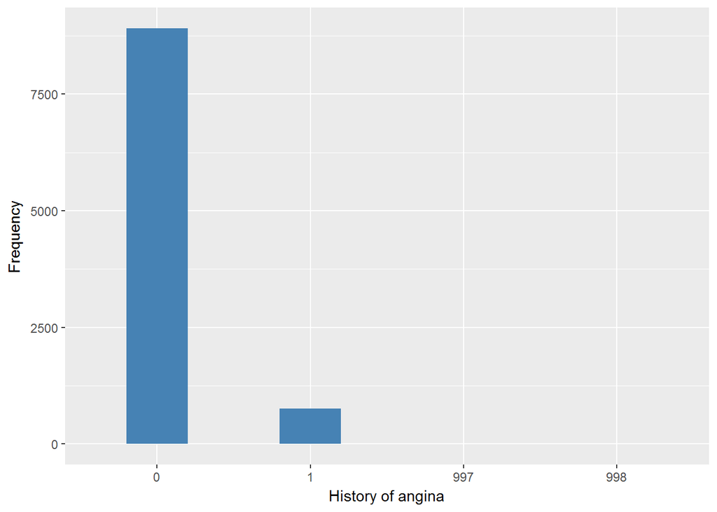

mi_ha

| Sample size | Missing values |
| --- | --- |
| 9666 | 6 |

Category

|  | 0 | 1 |
| --- | --- | --- |
| Frequency | 9554.00 | 106.0 |
| Percentage | 98.84 | 1.1 |

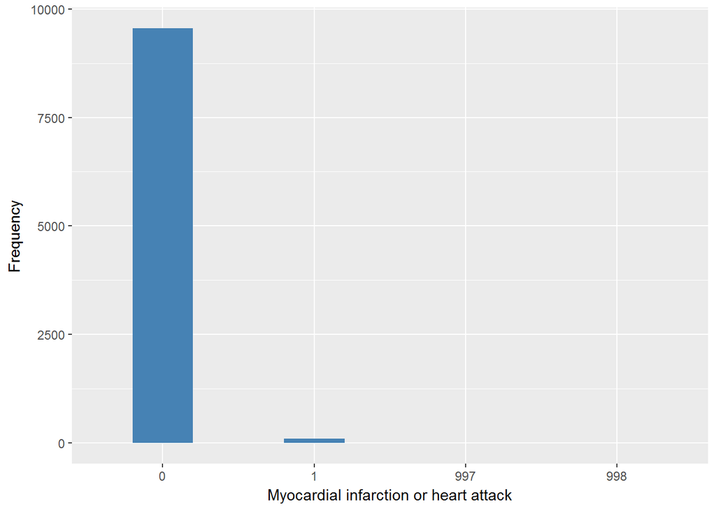

stroke

| Sample size | Missing values |
| --- | --- |
| 9666 | 6 |

Category

|  | 0 | 1 |
| --- | --- | --- |
| Frequency | 9522.00 | 138.00 |
| Percentage | 98.51 | 1.43 |

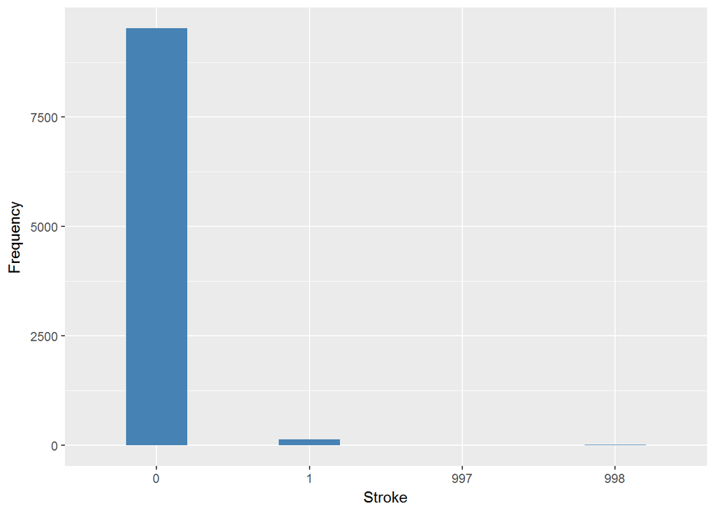

#### 2.1.7.2 Harmonisation algorithm

To compute `cvd_all` from the study-specific variable it has to be recoded as follows:

- `some 1 into 1`
- `all 0 into 0`
- `-9/997 into 997`
- `-8/998 into 998`

**R script:**

```r
# Categorical variable harmonization
ELSA_ds_w7 <- tibble(id = ELSA_w7$id)
ELSA_ds_w7$cvd_all <- rep(999, length(ELSA_w7$id))
ELSA_ds_w7$cvd_all[which(ELSA_w7$h_angina == 0 & ELSA_w7$mi_ha == 0 & ELSA_w7$stroke ==
    0 & ELSA_w7$hedimhf == 0 & ELSA_w7$hedimhm == 0)] <- 0
ELSA_ds_w7$cvd_all[which(ELSA_w7$h_angina == 1 | ELSA_w7$mi_ha == 1 | ELSA_w7$stroke ==
    1 | ELSA_w7$hedimhf == 1 | ELSA_w7$hedimhm == 1)] <- 1
ELSA_ds_w7$cvd_all[which(ELSA_w7$h_angina == 998 & ELSA_w7$mi_ha == 998 & ELSA_w7$stroke ==
    998 & ELSA_w7$hedimhf == -8 & ELSA_w7$hedimhm == -8)] <- 998
ELSA_ds_w7$cvd_all[which(ELSA_w7$h_angina == 997 & ELSA_w7$mi_ha == 997 & ELSA_w7$stroke ==
    997 & ELSA_w7$hedimhf == -9 & ELSA_w7$hedimhm == -9)] <- 997
```

#### 2.1.7.3 Statistics of the new harmonized variable

History of all Cardiovascular diseases

| Sample size | Missing values |
| --- | --- |
| 9666 | 6 |

Category

|  | 0 | 1 |
| --- | --- | --- |
| Frequency | 8652.00 | 1008.00 |
| Percentage | 89.51 | 10.43 |

Type of missing

|  | 991 | 992 | 993 | 994 | 995 | 996 | 997 | 998 | 999 | NA |
| --- | --- | --- | --- | --- | --- | --- | --- | --- | --- | --- |
| Frequency | 0 | 0 | 0 | 0 | 0 | 0 | 1.00 | 5.00 | 0 | 0 |
| Percentage | 0 | 0 | 0 | 0 | 0 | 0 | 0.01 | 0.05 | 0 | 0 |

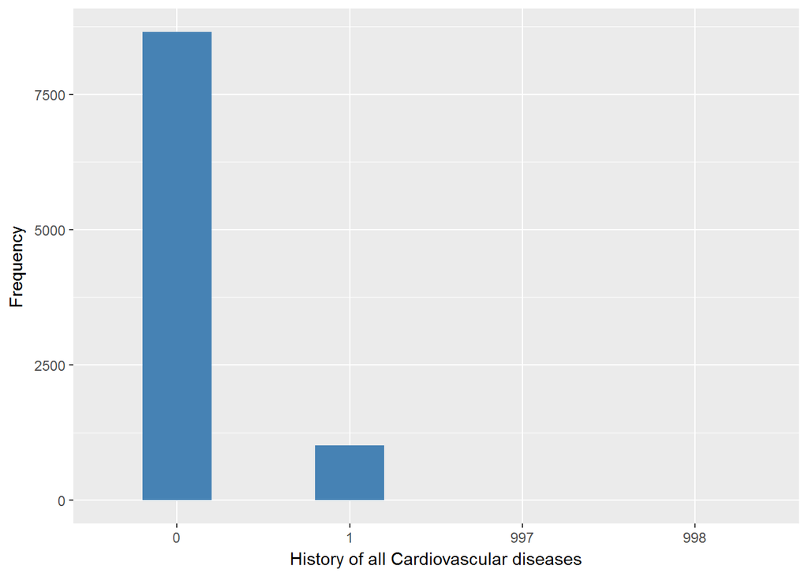

#### 2.1.7.4 Validation

|  | all 0->0 | some 1->1 | -9/997->997 | -8/998->998 |
| --- | --- | --- | --- | --- |
| BeforeH | 8652 | 1008 | 1 | 5 |
| AfterH | 8652 | 1008 | 1 | 5 |

## 2.2 Summary of descriptive statistics of the harmonised variable accross populations and waves

Two tables are generated:

1. Percentages of categories in each harmonised variable.
2. Frequencies and percentages of individuals with different trajectories. To avoid too large table, Only trajectories with percentages larger than 0.3 are shown.

**R script:**

```r
l.hds <- list(w1 = ELSA_ds_w1, w2 = ELSA_ds_w2, w3 = ELSA_ds_w3, w4 = ELSA_ds_w4,
    w5 = ELSA_ds_w5, w6 = ELSA_ds_w6, w7 = ELSA_ds_w7)

for (name in names(l.hds)) {
    aux_object <- l.hds[[name]]
    label(l.hds[[name]][[2]]) <- label(aux_object[[2]]) <- ds_label  # Text value assigned at the DS description, at the top
    l.hds[[name]][[2]] <- labelled(l.hds[[name]][[2]], labels = cat_label)
    aux_object[[2]] <- car::recode(aux_object[[2]], "miss_values_vector=NA")
    aux_object[[2]] <- labelled(aux_object[[2]], labels = cat_label[1:2])
    m_name <- paste0("ELSA_m_ds_", name)
    assign(m_name, aux_object)
    rm(aux_object)
}

t.hds <- frq(l.hds[[1]][2])[[1]][, c(1, 2)]
for (i in seq_along(l.hds)) {
    t.hds[2 + i] <- frq(l.hds[[i]][2])[[1]][, 4]
}
t.hds[13, ] <- c("n", "sample size", length(l.hds[[1]][[2]]), length(l.hds[[2]][[2]]),
    length(l.hds[[3]][[2]]), length(l.hds[[4]][[2]]), length(l.hds[[5]][[2]]),
    length(l.hds[[6]][[2]]), length(l.hds[[7]][[2]]))
names(t.hds) <- c("val", "label", "w1", "w2", "w3", "w4", "w5", "w6", "w7")
kable(t.hds)
```

| val | label | w1 | w2 | w3 | w4 | w5 | w6 | w7 |
| --- | --- | --- | --- | --- | --- | --- | --- | --- |
| 0 | No | 81.48 | 86.05 | 87.88 | 88.55 | 88.43 | 89.27 | 89.51 |
| 1 | Yes | 18.45 | 13.88 | 12.07 | 11.3 | 11.45 | 10.63 | 10.43 |
| 991 | CAPI interviewer error | 0 | 0 | 0 | 0 | 0 | 0 | 0 |
| 992 | Impute | 0 | 0 | 0 | 0 | 0 | 0 | 0 |
| 993 | Disable to measure | 0 | 0 | 0 | 0 | 0 | 0 | 0 |
| 994 | Not attempt not done | 0 | 0 | 0 | 0 | 0 | 0 | 0 |
| 995 | Does not answer | 0 | 0 | 0 | 0 | 0 | 0 | 0 |
| 996 | Not applicable | 0 | 0 | 0.05 | 0 | 0 | 0 | 0 |
| 997 | Refuse | 0.02 | 0.01 | 0 | 0.06 | 0.04 | 0.04 | 0.01 |
| 998 | Do not know | 0.05 | 0.06 | 0 | 0.08 | 0.09 | 0.06 | 0.05 |
| 999 | Missing | 0 | 0 | 0 | 0 | 0 | 0 | 0 |
| NA | NA | 0 | 0 | 0 | 0 | 0 | 0 | 0 |
| n | sample size | 12099 | 9432 | 9771 | 11050 | 10274 | 10601 | 9666 |

```r
dbb <- merge(ELSA_m_ds_w1[, c("id", "cvd_all")], ELSA_m_ds_w2[, c("id", "cvd_all")],
    by = "id", suffixes = c(".w1", ".w2"), all = T)
dbb <- merge(dbb, ELSA_m_ds_w3[, c("id", "cvd_all")], by = "id", all = T)
dbb <- merge(dbb, ELSA_m_ds_w4[, c("id", "cvd_all")], by = "id", suffixes = c(".w3",
    ".w4"), all = T)
dbb <- merge(dbb, ELSA_m_ds_w5[, c("id", "cvd_all")], by = "id", all = T)
dbb <- merge(dbb, ELSA_m_ds_w6[, c("id", "cvd_all")], by = "id", suffixes = c(".w5",
    ".w6"), all = T)
dbb <- merge(dbb, ELSA_m_ds_w7[, c("id", "cvd_all")], by = "id", all = T)
names(dbb) <- c("id", "w1", "w2", "w4", "w5")
v.dbb <- paste(dbb[, 2], dbb[, 3], dbb[, 4], dbb[, 5], dbb[, 6], dbb[, 7], dbb[,
    8], sep = "")
f.dbb <- frq(v.dbb)[[1]][, c(1, 2, 4)]
kable(f.dbb[f.dbb[, 3] >= 0.3, ])
```

|  | val | frq | raw.prc |
| --- | --- | --- | --- |
| 1 | 0000000 | 3280 | 17.74 |
| 2 | 0000001 | 92 | 0.50 |
| 3 | 000000NA | 440 | 2.38 |
| 9 | 00000NANA | 314 | 1.70 |
| 10 | 0000100 | 65 | 0.35 |
| 24 | 0000NANANA | 401 | 2.17 |
| 39 | 000NA000 | 95 | 0.51 |
| 56 | 000NANANANA | 627 | 3.39 |
| 83 | 00NA0000 | 86 | 0.47 |
| 117 | 00NANANANANA | 943 | 5.10 |
| 173 | 0NA00000 | 70 | 0.38 |
| 201 | 0NA0NANANANA | 88 | 0.48 |
| 212 | 0NANA0000 | 60 | 0.32 |
| 246 | 0NANANANANANA | 1584 | 8.57 |
| 247 | 1000000 | 189 | 1.02 |
| 283 | 100NANANANA | 78 | 0.42 |
| 307 | 10NANANANANA | 107 | 0.58 |
| 325 | 1111111 | 271 | 1.47 |
| 326 | 111111NA | 77 | 0.42 |
| 328 | 11111NANA | 59 | 0.32 |
| 332 | 1111NANANA | 94 | 0.51 |
| 339 | 111NANANANA | 120 | 0.65 |
| 356 | 11NANANANANA | 191 | 1.03 |
| 406 | 1NANANANANANA | 498 | 2.69 |
| 446 | NANA00000 | 781 | 4.22 |
| 448 | NANA0000NA | 108 | 0.58 |
| 452 | NANA000NANA | 75 | 0.41 |
| 462 | NANA00NANANA | 111 | 0.60 |
| 489 | NANA0NANANANA | 286 | 1.55 |
| 519 | NANANA0000 | 1466 | 7.93 |
| 521 | NANANA000NA | 211 | 1.14 |
| 527 | NANANA00NANA | 155 | 0.84 |
| 543 | NANANA0NANANA | 316 | 1.71 |
| 555 | NANANA1111 | 61 | 0.33 |
| 565 | NANANANA000 | 71 | 0.38 |
| 578 | NANANANANA00 | 861 | 4.66 |
| 580 | NANANANANA0NA | 252 | 1.36 |
| 584 | NANANANANANA0 | 478 | 2.59 |

# 3 Quality estimation

The harmonized variable contains information about: angina, myocardial infarction, stroke, congestive heart failure and heart murmur.